# **Módulo 2: Introducción al manejo de datos espaciales**

Handling spatial vector data

Sergio A. Barona

Laboratorio de Economía Aplicada (LEA)

Departamento de Economía y Finanzas

21-04-2025

# 1 El paquete sf

El paquete sf puede ser usado para representar y trabajar con spatial vector data (points, polygons, and lines) y su información asociada (Pebesma, 2022 a)

# 2 Objeto sf:

## 2.1 sf object

- sf (simple feature): each row of the data.frame is a single simple feature consisting of attributes and geometry.
- sfc (simple feature geometry list-column): the geometry column of the data.frame is a list-column of class sfc with the geometry of each simple feature.
- sfg (simple feature geometry): each of the rows of the sfc list-column corresponds to the simple feature geometry (sfg) of a single simple feature.

## 2.2 Leer sf object

Como vimos en la sesión pasada, podemos leer un objeto *sf* con la función ´st_read()´.

Un ejemplo: leemos el shapefile ´dpto.col´, que contiene los departamentos de Colombia:

```r
library(sf)
dpto.col = st_read(dsn = "C:\\Users\\sergio.barona\\Desktop\\SpatialData-Workshop\\vector_data\\nbi_dptos\\",
            layer = "dptoscol_nbi_cnpv2018")
class(dpto.col)
```

```
## [1] "sf"         "data.frame"
```

```r
print(dpto.col)
```

```
## Simple feature collection with 33 features and 11 fields
## Geometry type: MULTIPOLYGON
## Dimension:     XY
## Bounding box:  xmin: -81.73882 ymin: -4.228614 xmax: -66.84722 ymax: 13.39736
## Geodetic CRS:  WGS 84
## First 10 features:
##    ID_ESPA AREA_OF cod         dpto tasa_nb tas_msr comp_vv cmp_srv cmp_hcn
## 1       11    1605  11 BOGOTÁ, D.C.    3.36    0.24    0.36    0.10    1.35
## 2       13   26383  13      BOLÍVAR   26.56    8.02   13.16    9.55    4.68
## 3       15   23189  15       BOYACÁ   10.04    1.89    2.33    1.80    3.13
## 4       17    7888  17       CALDAS    8.91    1.52    1.74    1.55    2.04
## 5       18   88965  18      CAQUETÁ   23.48    6.16   10.12    5.91    4.61
## 6       19   29308  19        CAUCA   18.27    3.15    5.99    5.87    3.71
## 7       20   22905  20        CESAR   22.82    7.17    9.31    5.04    7.88
## 8       23   26506  23     CÓRDOBA    34.82   11.16   25.99    6.16    6.90
## 9       25   22605  25 CUNDINAMARCA    6.26    0.72    1.41    0.63    1.85
## 10      27   46530  27        CHOCÓ   65.40   20.22    8.52   57.42   12.71
##    cmp_nss cmp_dp_                       geometry
## 1     1.01    0.79 MULTIPOLYGON (((-74.06964 4...
## 2     3.15    6.12 MULTIPOLYGON (((-75.256 10....
## 3     1.31    4.49 MULTIPOLYGON (((-72.15949 7...
## 4     1.21    4.34 MULTIPOLYGON (((-74.67036 5...
## 5     2.91    7.59 MULTIPOLYGON (((-74.78494 2...
## 6     1.52    4.93 MULTIPOLYGON (((-76.44672 3...
## 7     3.09    7.59 MULTIPOLYGON (((-73.39171 1...
## 8     1.81    8.40 MULTIPOLYGON (((-75.87806 9...
## 9     1.33    1.85 MULTIPOLYGON (((-74.31495 5...
## 10    4.54   10.86 MULTIPOLYGON (((-77.3654 8....
```

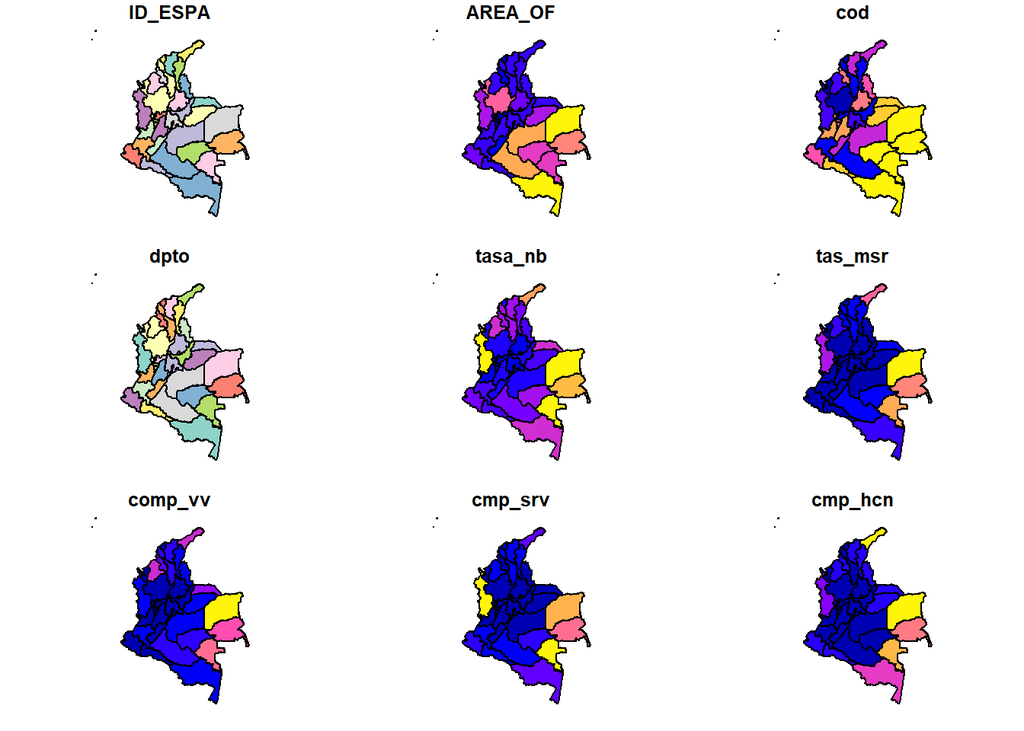

```r
plot(dpto.col)
```

## 2.3 Nota: visualizar sf object

Después de cargar el objeto *sf* podemos realizar la visualización a través de la librería **ggplot2**, específicamente utilizando la función **geom_sf()** para dibujar las geometrías espaciales.

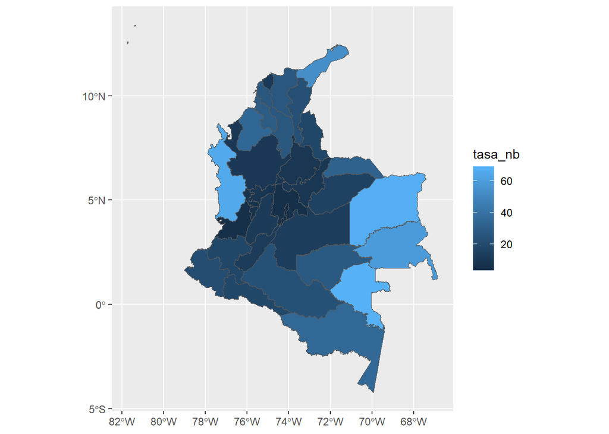

```r
library(ggplot2)
ggplot(dpto.col) + geom_sf(aes(fill = tasa_nb))
```

Elementos adicionales se pueden incorporar a la visualización:

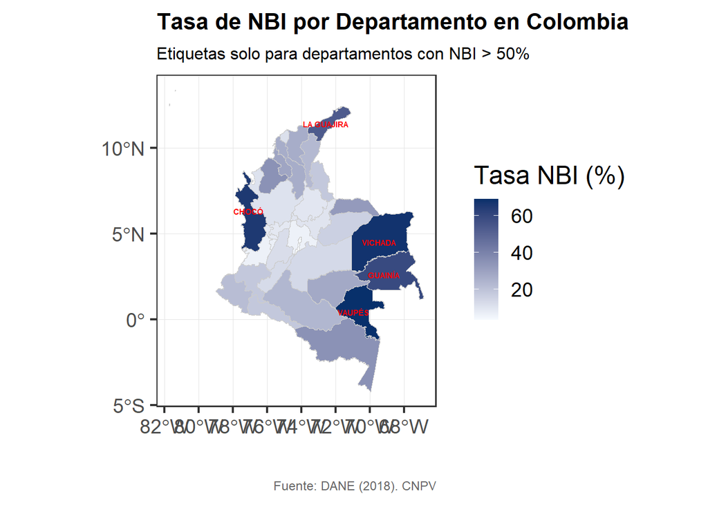

```r
library(tidyverse)
ggplot(dpto.col) +
  geom_sf(aes(fill = tasa_nb), color = "grey80", size = 0.3) +
  geom_sf_text(
    data = dpto.col %>% filter(tasa_nb > 50),
    aes(label = dpto),
    size = 2, color = "red", fontface = "bold"
  ) +
  scale_fill_gradient(
    low = "#f7fbff",
    high = "#08306b",
    name = "Tasa NBI (%)"
  ) +
  theme_bw(base_size = 18) +
  theme(
    legend.position = "right",
    panel.grid.major = element_line(color = "grey90", size = 0.2),
    plot.title = element_text(face = "bold", size = 16),
    plot.subtitle = element_text(size = 12),
    plot.caption = element_text(size = 9, color = "grey40")
  ) +
  labs(
    title = "Tasa de NBI por Departamento en Colombia",
    subtitle = "Etiquetas solo para departamentos con NBI > 50%",
    caption = "Fuente: DANE (2018). CNPV",
    x = " ", y = " "
  ) +
  coord_sf()
```

## 2.4 Crear sf object (añadir en la diapositiva)

Podemos crear un objeto *sf* proporcionando los dos elementos que la componen:

1. A *dataframe* with the attributes of each feature
2. A simple feature geometry list-column *sfc* containing simple feature geometries *sfg* (por ejemplo, puntos, conjuntos de puntos, polígonos, etc.).

Aquí un ejemplo (CAMBIAR EL EJEMPLO):

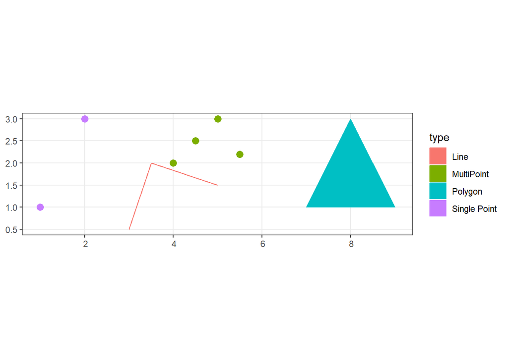

```r
# Create geometries
pt1 <- st_point(c(1, 1))
pt2 <- st_point(c(2, 3))
mp  <- st_multipoint(rbind(c(4, 2), c(5, 3), c(4.5, 2.5), c(5.5, 2.2)))
poly <- st_polygon(list(rbind(c(7, 1), c(9, 1), c(8, 3), c(7, 1))))
line <- st_linestring(rbind(c(3, 0.5), c(3.5, 2), c(5, 1.5)))

# Combine into an sfc
geoms <- st_sfc(pt1, pt2, mp, poly, line)

# Add attributes
df <- data.frame(
  name = c("Alpha", "Beta", "Gamma", "Delta", "Epsilon"),
  type = c("Single Point", "Single Point", "MultiPoint", "Polygon", "Line"),
  value = c(10, 20, 30, 40, 50)
)

sf_obj <- st_sf(df, geometry = geoms)

# Plot single points, set of points and polygon
library(ggplot2)
ggplot(sf_obj) + geom_sf(aes(col = type, fill = type), size = 3) + theme_bw()
```

En la subsección “st_as_sf”, se verá un ejemplo más aplicado, donde podemos utilizar la creación de objetos sf.

# 3 Selección de elementos

La indexación en los datos vectoriales espaciales funcionan de la siguiente manera:

```r
# Seleccionar la variable
dpto.col$tasa_nb
```

```
##  [1]  3.36 26.56 10.04  8.91 23.48 18.27 22.82 34.82  6.26 65.40 12.68 53.01
## [13] 26.50 13.31 21.59 18.26  6.73  8.14  9.45 28.98 12.06  6.18 32.26 15.89
## [25] 18.41    NA 34.92 59.21 27.80 68.89 67.62 10.67 11.28
```

```r
# Es diferente de:
dpto.col["tasa_nb"]
```

```
## Simple feature collection with 33 features and 1 field
## Geometry type: MULTIPOLYGON
## Dimension:     XY
## Bounding box:  xmin: -81.73882 ymin: -4.228614 xmax: -66.84722 ymax: 13.39736
## Geodetic CRS:  WGS 84
## First 10 features:
##    tasa_nb                       geometry
## 1     3.36 MULTIPOLYGON (((-74.06964 4...
## 2    26.56 MULTIPOLYGON (((-75.256 10....
## 3    10.04 MULTIPOLYGON (((-72.15949 7...
## 4     8.91 MULTIPOLYGON (((-74.67036 5...
## 5    23.48 MULTIPOLYGON (((-74.78494 2...
## 6    18.27 MULTIPOLYGON (((-76.44672 3...
## 7    22.82 MULTIPOLYGON (((-73.39171 1...
## 8    34.82 MULTIPOLYGON (((-75.87806 9...
## 9     6.26 MULTIPOLYGON (((-74.31495 5...
## 10   65.40 MULTIPOLYGON (((-77.3654 8....
```

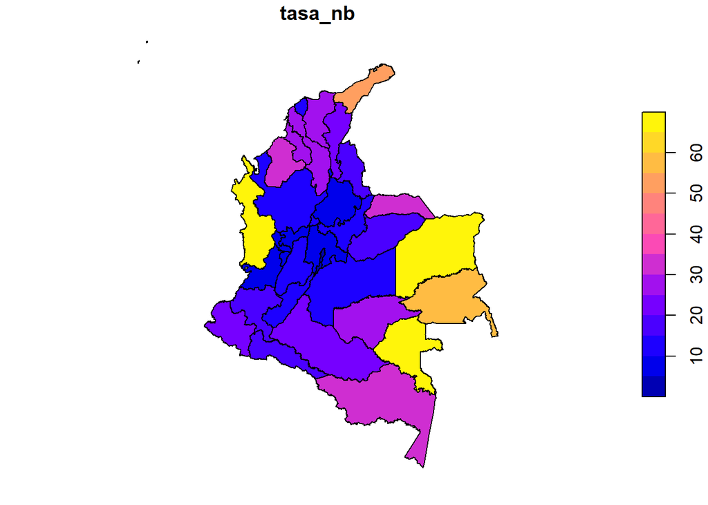

```r
plot(dpto.col["tasa_nb"])
```

# 4 Joining data and creat map

Uno de los ejercicios más frecuentes en la visualización de datos espaciales es la unión de diferentes fuentes de datos.

Aquí presento un ejemplo: supongamos que queremos añadir la información sobre los ingresos corrientes e ingresos totales de cada municipio de Colombia, usando la información del DNP.

Paso 1: cargamos los spatial vector data:

```r
mun_shape <- st_read(dsn = "C:\\Users\\sergio.barona\\Desktop\\SpatialData-Workshop\\vector_data\\\\DANE_geodata\\",
                      layer = "MGN_ANM_MPIOS") %>% mutate(
                        cod = as.numeric(
                          paste0(DPTO_CCDGO, MPIO_CCDGO))
                      )
head(mun_shape)
```

```
## Simple feature collection with 6 features and 91 fields
## Geometry type: MULTIPOLYGON
## Dimension:     XY
## Bounding box:  xmin: -76.1027 ymin: 0.9764735 xmax: -74.89527 ymax: 2.326755
## Geodetic CRS:  MAGNA-SIRGAS
##   DPTO_CCDGO MPIO_CCDGO             MPIO_CNMBR MPIO_CDPMP VERSION       AREA
## 1         18        001              FLORENCIA      18001    2018 2547637532
## 2         18        029                ALBANIA      18029    2018  414122070
## 3         18        094 BELÉN DE LOS ANDAQUÍES      18094    2018 1191618572
## 4         18        247            EL DONCELLO      18247    2018 1106076151
## 5         18        256              EL PAUJÍL      18256    2018 1234734145
## 6         18        410           LA MONTAÑITA      18410    2018 1701061430
##    LATITUD  LONGITUD STCTNENCUE STP3_1_SI STP3_2_NO STP3A_RI STP3B_TCN
## 1 1.749139 -75.55824      71877        32     71845       32         0
## 2 1.227865 -75.88233       2825        24      2801       24         0
```

[output cut: 88 more lines]

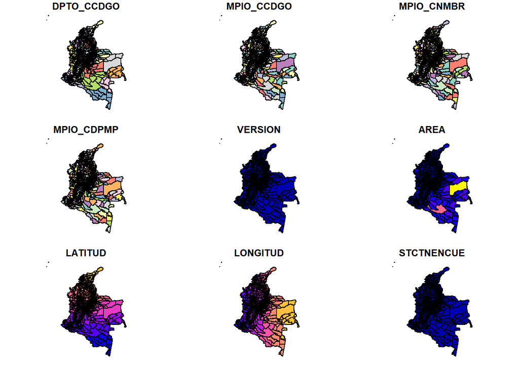

```r
plot(mun_shape)
```

Paso 2: cargamos los datos del DNP

```r
ing_dnp <- readxl::read_excel("C:\\Users\\sergio.barona\\Desktop\\SpatialData-Workshop\\vector_data\\CNPV_2018\\INGRESOS_MUN_DNP.xlsx")

summary(ing_dnp)
```

```
##     cod_dpto       nom_dpto            cod_mun        nom_mun
##  Min.   : 5.00   Length:1102        Min.   :  1.0   Length:1102
##  1st Qu.:15.00   Class :character   1st Qu.:212.0   Class :character
##  Median :25.00   Mode  :character   Median :419.5   Mode  :character
##  Mean   :37.29                      Mean   :430.3
##  3rd Qu.:63.00                      3rd Qu.:664.0
##  Max.   :99.00                      Max.   :980.0
##       cod        ingresos_totales   ingresos_corrientes    corr_tot
##  Min.   : 5001   Min.   :       0   Min.   :       0    Min.   :0.0000
##  1st Qu.:15650   1st Qu.:   11085   1st Qu.:    2468    1st Qu.:0.1156
##  Median :25783   Median :   17621   Median :    3762    Median :0.1648
##  Mean   :37723   Mean   :   66595   Mean   :   26828    Mean   :0.1880
##  3rd Qu.:63376   3rd Qu.:   32301   3rd Qu.:    7827    3rd Qu.:0.2323
##  Max.   :99773   Max.   :15606995   Max.   :10210852    Max.   :1.6021
```

Paso 3: realizamos la unión a través de los operadores join (left_join, right_join, full_join, inner_join, etc.)

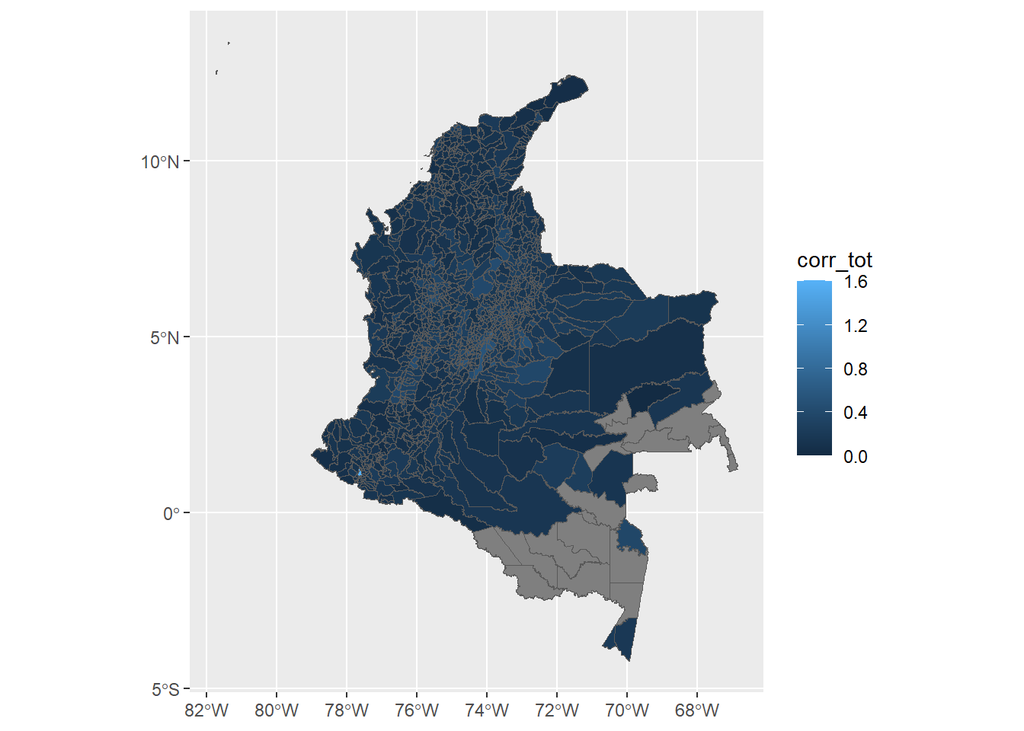

```r
mun.col <-  mun_shape[c("cod",
                             "geometry")] %>%
  left_join(ing_dnp,by = "cod")

ggplot(mun.col) + geom_sf(aes(fill = corr_tot))
```

**Ejercicio:** añadir los datos sobre la población total.

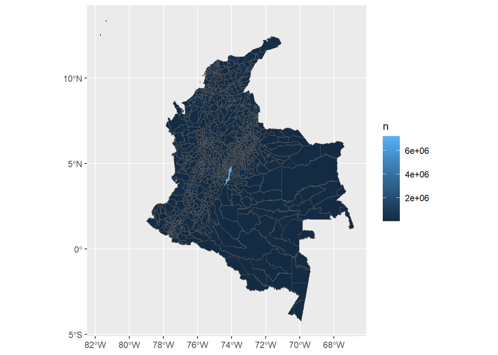

```r
pob <- readxl::read_excel("C:\\Users\\sergio.barona\\Desktop\\SpatialData-Workshop\\vector_data\\CNPV_2018\\Pob_MUN_CNPV2018.xlsx")

mun.col <-  mun.col %>%
  left_join(pob[c("cod", "n")],by = "cod")

ggplot(mun.col) + geom_sf(aes(fill = n))
```

# 5 Funciones st_*()

Hay funciones ampliamente utilizadas para manejar objetos *sf*. Aquí algunas:

- st_read() reads a sf object
- st_write() writes a sf object
- st_crs() gets or sets a new coordinate reference system (CRS)
- st_transform() transforms data to a new CRS
- st_intersection() intersects sf objects
- st_union() combines several sf objects into one
- st_simplify() simplifies a sf object
- st_coordinates() retrieves coordinates of a sf object
- st_as_sf() converts a foreign object to a sf object

En lo sucesivo, examinamos algunas aplicaciones utilizando estas funciones.

## 5.1 st_union

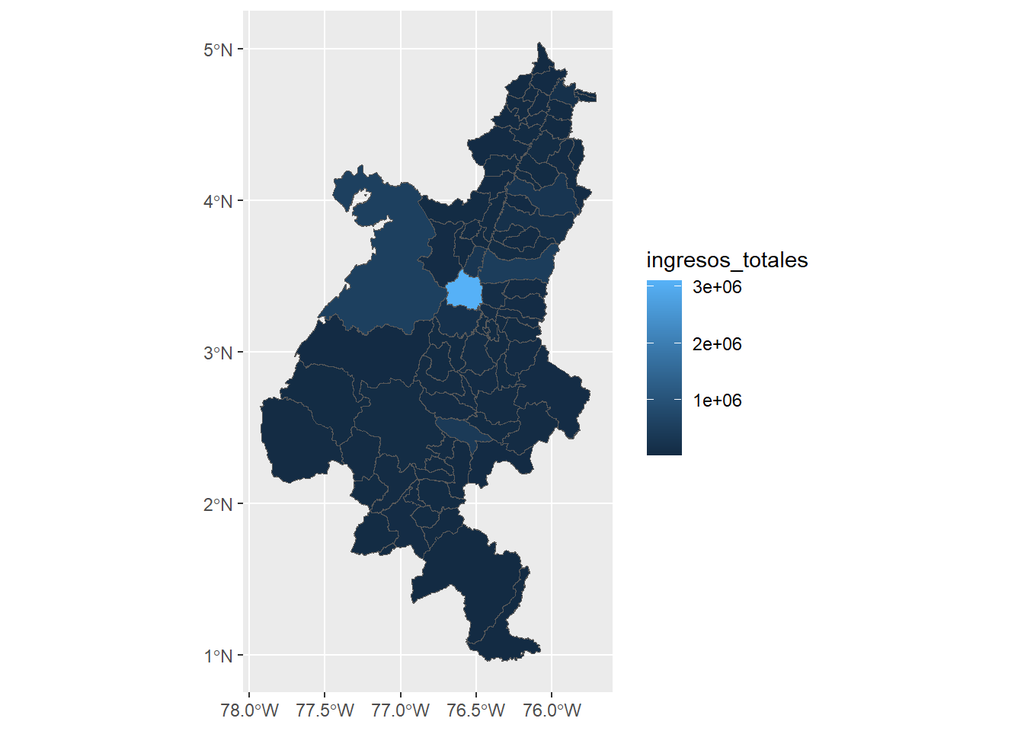

```r
# Examinemos el caso de dos departamentos: Valle del Cauca y Cauca
valle_cauca <- mun.col %>% filter(nom_dpto %in% c("VALLE DEL CAUCA", "CAUCA"))

ggplot(valle_cauca) + geom_sf(aes(fill = ingresos_totales))
```

Supongamos que queremos una unión entre el Valle del Cauca y el Cauca. Así que, para ello, podemos utilizar la función ´st_union()´:

```r
# Primero, definimos la unión para un departamento
valle = mun.col %>% filter(nom_dpto == "VALLE DEL CAUCA")

valle_union <- valle %>%
  summarise(
    nom_dpt = unique(nom_dpto),
    total_pop = sum(n),
    total_ing = sum(ingresos_totales),
    total_corr = sum(ingresos_corrientes),
    dpto_corr_tt = total_corr/total_ing,
    geometry = st_union(geometry)
  )

print(valle_union)
```

```
## Simple feature collection with 1 feature and 5 fields
## Geometry type: MULTIPOLYGON
## Dimension:     XY
## Bounding box:  xmin: -77.54977 ymin: 3.091239 xmax: -75.70724 ymax: 5.047394
## Geodetic CRS:  MAGNA-SIRGAS
##           nom_dpt total_pop total_ing total_corr dpto_corr_tt
## 1 VALLE DEL CAUCA   3789874   6037568    2786702    0.4615604
##                         geometry
## 1 MULTIPOLYGON (((-75.88026 4...
```

**Posible ejercicio**: ¿Cómo podríamos hacer la unión para todos los departamentos? **Pista**: usar la función **group_by()**:

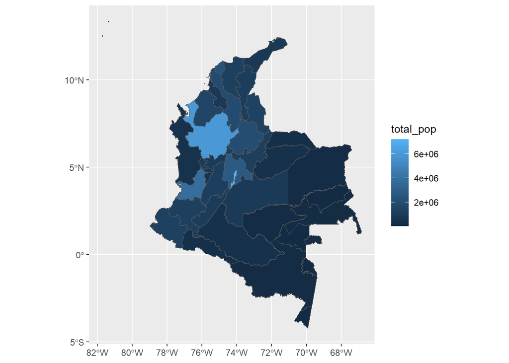

```r
# Primero, definimos la unión para un departamento
dptos_union <- mun.col %>%
  group_by(nom_dpto) %>%
  summarise(
    nom_dpt = unique(nom_dpto),
    total_pop = sum(n),
    total_ing = sum(ingresos_totales),
    total_corr = sum(ingresos_corrientes),
    dpto_corr_tt = total_corr/total_ing,
    geometry = st_union(geometry)
  )

# ¿Cómo se vería?
ggplot(dptos_union) + geom_sf(aes(fill = total_pop))
```

## 5.2 st_simplify

Aún no encuentro exactamente la utilidad de explicar st_simplify. Pero aquí un ejemplo:

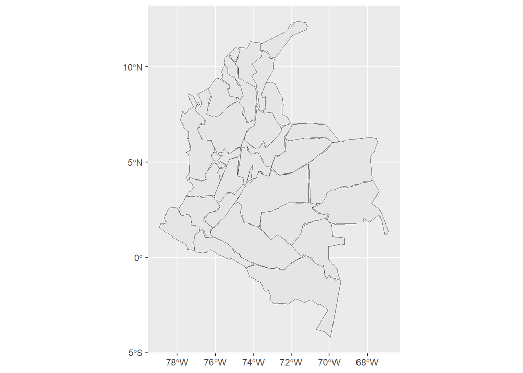

```r
dptos_simplify = st_simplify(dpto.col, dTolerance = 10000)

ggplot(dptos_simplify) + geom_sf()
```

## 5.3 st_as_sf

Una aplicación común es la creación de objetos **sf** para añadir a nuestros datos.

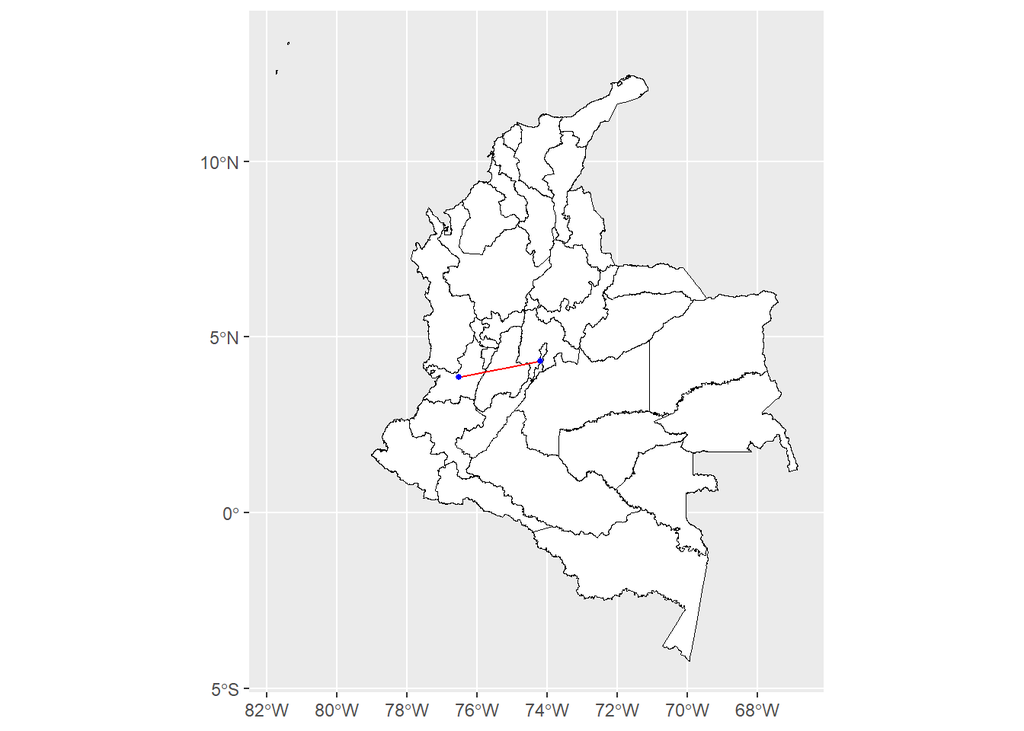

```r
# Extraer centroides
cent.dptos <- st_centroid(dpto.col)

# Obtener coordenadas de los centroides
valle <- cent.dptos %>% filter(cod == 76) %>% st_coordinates()
bogota <- cent.dptos %>% filter(cod == 11) %>% st_coordinates()

# Crear la línea como sfc y luego como sf
line_vb <- st_sfc(st_linestring(rbind(valle, bogota)), crs = st_crs(dpto.col))
line_sf <- st_sf(geometry = line_vb)

# Graficar
ggplot() +
  geom_sf(data = dpto.col, fill = "white", color = "black") +
  geom_sf(data = line_sf, color = "red", size = 1.2) +
  geom_sf(data = cent.dptos %>% filter(cod %in% c(76, 11)),
          color = "blue", size = 1)
```

Otra aplicación común es añadir puntos en lugares específicos de interés. Veamos un ejemplo: supongamos que queremos añadir un indicador para un punto de referencia en una ciudad. Ejemplo: parque Simón Bolívar (4.658164647475244, -74.09413442050968).

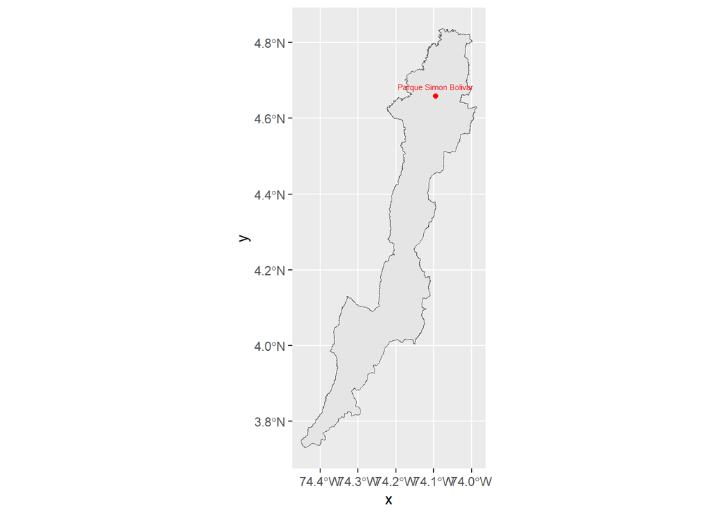

```r
# Filtrar la geometría para Bogotá
bogota = mun.col %>% filter(cod_dpto == 11)

# Crear las coordenadas de interés:
aux.coord <- data.frame(
place = c("Parque Simon Bolivar"),
long = c(-74.09413442050968),
lat = c(4.658164647475244)) %>% st_as_sf(coords = c("long", "lat"))

# Fijar el CRS
st_crs(aux.coord) = st_crs(bogota)

# Visualizar
ggplot() + geom_sf(data = bogota) +
  geom_sf(data = aux.coord, col = "red") +
  geom_sf_text(data = aux.coord,
                aes(label = place),
                size = 2, vjust = -1, col = "red")
```